# R4DS - Data Vis

We can get the number of column and rows of a dataset by using the nrow and ncol functions.

```r
ncol(mpg)
```

```
## [1] 11
```

```r
nrow(mpg)
```

```
## [1] 234
```

So, using the logic from above, we can get a scatter plot of the `hwy` and `cyl` variables like so.

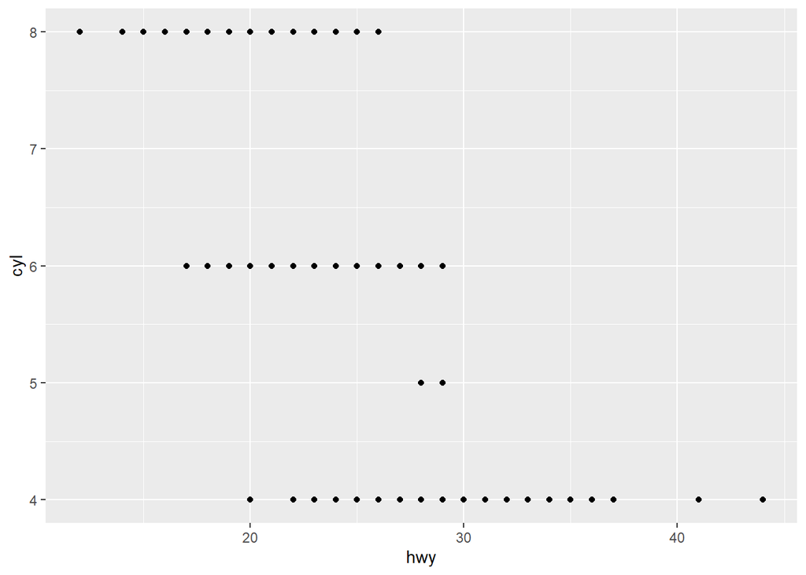

```r
ggplot(data=mpg) +
  geom_point(mapping = aes(x=hwy, y=cyl))
```

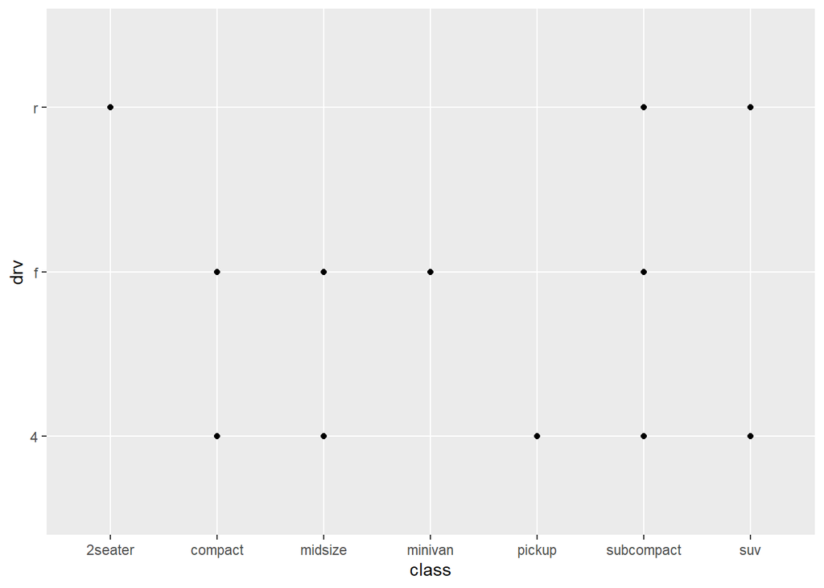

```r
ggplot(data=mpg) +
  geom_point(mapping = aes(x=class, y=drv))
```

Obviously, this plot isn’t very useful because we are looking at two categorical variables. The points are just telling us that these observations exist, but tells us nothing more about these points.

We can color the points using the aesthetic function inside of the geoms:

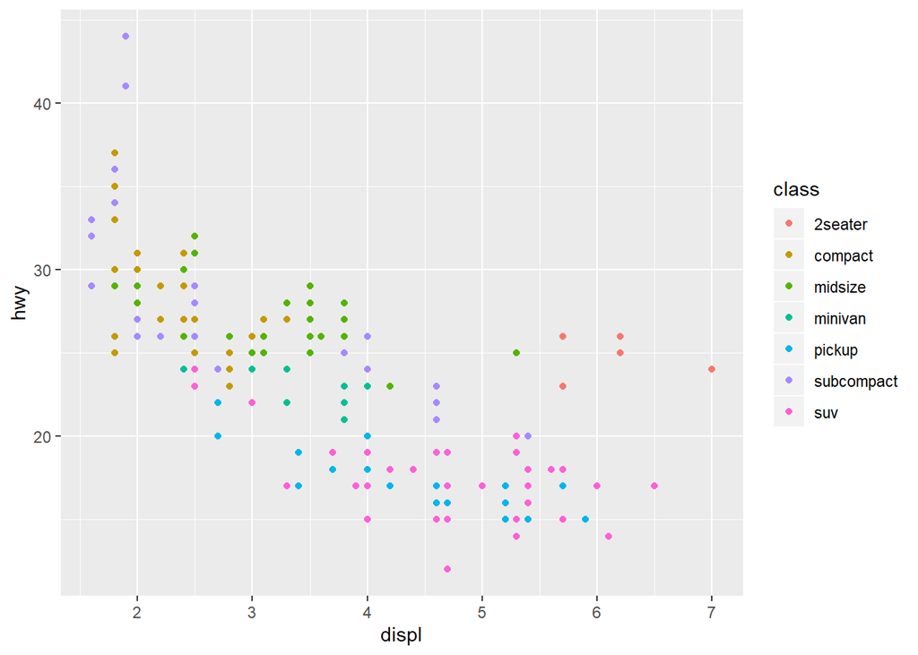

```r
ggplot(data=mpg) +
  geom_point(mapping=aes(x=displ, y=hwy, color=class))
```

We can how see where the different classifications of cars are concentrated in this graph. The colors are all mapped automatically for us which saves us having to write something like a for-loop like we might for other visualisation packages.